# Barbiero_Lorenzo_rlab03

Barbiero Lorenzo

2023-05-15

```r
library(tidyverse)
library(ggpubr)
```

## Exercise 1

For aesthetic reasons I will keep the distributions in separate plots

### Uniform prior

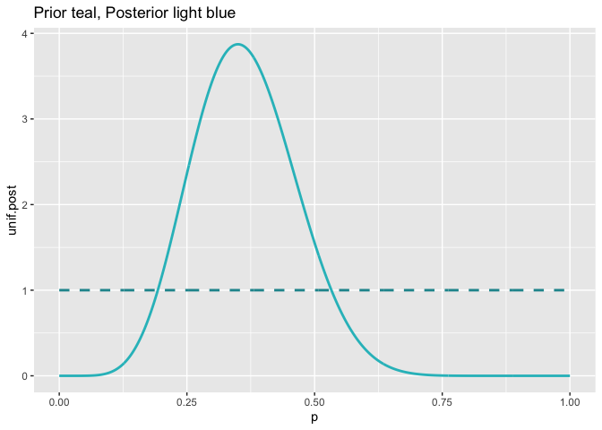

```r
p <- seq(0,1,0.001)
unif.prior <- dbeta(p,1,1)
unif.post <- dbeta(p,8,14)
UNIF <- data.frame(p,unif.prior,unif.post)
q <- pbeta(0.5,8,13)
(plt<-ggplot(UNIF)+geom_line(aes(p,unif.post), color="#29bdc5", lwd=1)
  +geom_line(aes(p,unif.prior), color="#20949c", lwd=1, linetype="dashed")+
    ggtitle("Prior teal, Posterior light blue"))
```

### Jeffrey’s prior

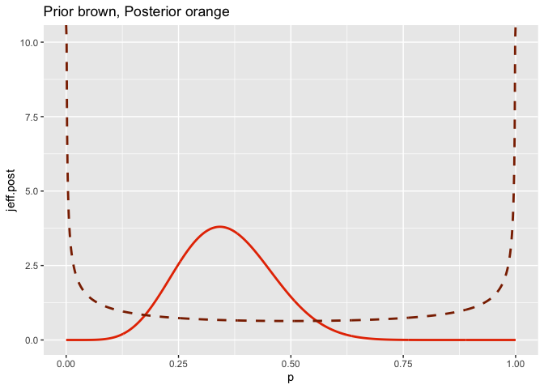

```r
jeff.prior <- dbeta(p,0.5,0.5)
jeff.post <- dbeta(p,0.5+7,0.5+13)
JEFF <- data.frame(p,jeff.prior,jeff.post)
(plt<-ggplot(JEFF) + geom_line(aes(p,jeff.post), color="#e63900", lwd=1)+
    geom_line(aes(p,jeff.prior), color="#8b2900", lwd=1, linetype="dashed")+
    ggtitle("Prior brown, Posterior orange"))
```

### Custom prior

define custom prior

```r
x <- seq(0,1,0.01)
custprior <- function(x) {
  custprior <- ifelse(x<0.2,x,
              ifelse(x<0.3,0.2,
                     ifelse(x<0.5,0.5-x,0)))
  return(custprior)
}

Int <- integrate(custprior,0,1)$value
cprior <- custprior(p) / integrate(custprior,0,1)$value
```

compute posterior

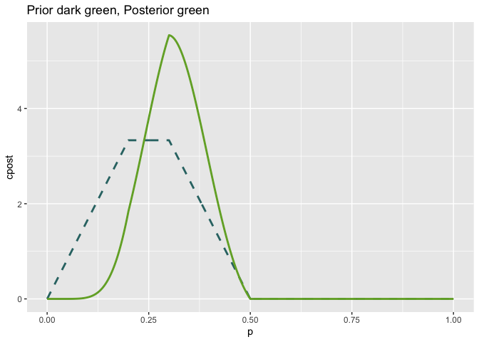

```r
custompost <- function(x,r=7,n=20) {
  cpost <- custprior(x) * dbinom(7,20,x)
  return(cpost)
}
int <- integrate(custompost,0,1)$value
cpost <- custompost(p)/integrate(custompost,0,1)$value
CUST <- data.frame(p,cpost,cprior)
(plt<-ggplot(CUST))+geom_line(aes(p,cpost)) +
  geom_line(aes(p,cprior), linetype = "dashed", color = "#317373", lwd=1) +
  geom_line(aes(p,cpost), color = "#73ac31", lwd=1)+
  ggtitle("Prior dark green, Posterior green")
```

Compute first two moments

```r
mnf <- function(x){return(custompost(x)*x)}
mn <- integrate(mnf,0,1)$value/integrate(custompost,0,1)$value
mn
```

```
## [1] 0.3120333
```

```r
vrf <- function(x){return(custompost(x)*(x-mn)**2)}
vr <- integrate(vrf,0,1)$value/integrate(custompost,0,1)$value
vr
```

```
## [1] 0.004994845
```

Compute 95% quantile

```r
cust.quant <- function(x,low,up) {
  for (i in x) {
    int <- integrate(custompost,0,i)$value/integrate(custompost,0,1)$value
    if (int < low) {
      lbound <- i
    }
    if (int < up) {
      ubound <- i
    }
  }
  return(c(lbound,ubound))
}

q <- cust.quant(p,0.025,0.975)
```

### Results comparison

Summary table

```r
var_beta <- function(alpha,beta) {return((alpha*beta)/(((alpha+beta)**2)*(alpha+beta+1)))}

quantities <- c("First moment","Second Moment","lower quantile","upper quantile")
flat_prior <- c(8/22,var_beta(8,14),qbeta(0.025,8,14),qbeta(0.975,8,14))
jeff_prior <- c(7.5/21,var_beta(7.5,13.5),qbeta(0.025,7.5,13.5),qbeta(0.975,7.5,13.5))
custom_prior <- c(mn,vr,q[1],q[2])
summary <- data.frame(quantities,flat_prior,jeff_prior,custom_prior)
summary
```

```
##       quantities flat_prior jeff_prior custom_prior
## 1   First moment 0.36363636 0.35714286  0.312033301
## 2  Second Moment 0.01006109 0.01043599  0.004994845
## 3 lower quantile 0.18107163 0.17227621  0.175000000
## 4 upper quantile 0.56967548 0.56776609  0.447000000
```

Plots

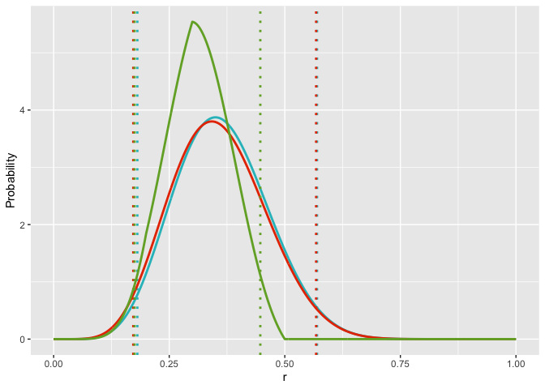

```r
(plt <- ggplot(UNIF) + geom_line(aes(p,unif.post), color="#29bdc5", lwd=1)+
   geom_vline(xintercept=qbeta(0.025,8,14), color="#29bdc5", linetype="dotted", lwd=1) +
   geom_vline(xintercept=qbeta(0.975,8,14), color="#29bdc5", linetype="dotted", lwd=1) +
   geom_line(data=JEFF, aes(p,jeff.post), color="#e63900", lwd=1) +
   geom_vline(xintercept=qbeta(0.025,7.5,13.5), color="#e63900", linetype="dotted", lwd=1) +
   geom_vline(xintercept=qbeta(0.975,7.5,13.5), color="#e63900", linetype="dotted", lwd=1) +
   geom_line(data=CUST, aes(p,cpost), color = "#73ac31", lwd=1) +
   geom_vline(xintercept=q[1], color="#73ac31", linetype="dotted", lwd=1) +
   geom_vline(xintercept=q[2], color="#73ac31", linetype="dotted", lwd=1) +
   labs(x="r",y="Probability")
 )
```

## Exercise 2

The experiment is clearly a Bernoulli process with r=17 and n=116

### Uniform prior vs Beta prior

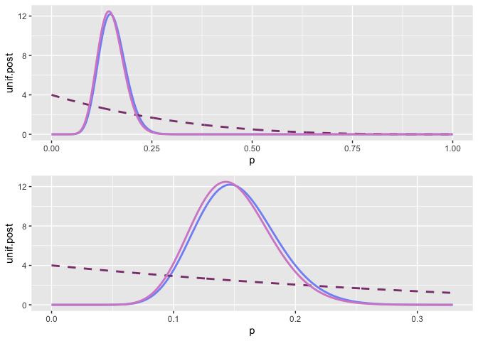

```r
unif.post <- dbeta(p,18,100)
beta.prior <- dbeta(p,1,4)
beta.post <- dbeta(p,18,103)

X <- data.frame(p,unif.post,beta.prior,beta.post)

plt<-ggplot(X)+geom_line(aes(p,unif.post),color="#8394f6", lwd=1) +
  geom_line(aes(p,beta.prior), linetype="dashed", color="#8b417b", lwd=1) +
  geom_line(aes(p,beta.post), color="#d58bcd", lwd=1)

qlt<-ggplot(X[X$p<0.33,])+geom_line(aes(p,unif.post),color="#8394f6", lwd=1) +
  geom_line(aes(p,beta.prior), linetype="dashed", color="#8b417b", lwd=1) +
  geom_line(aes(p,beta.post), color="#d58bcd", lwd=1)

(plot <- ggarrange(plt,qlt, nrow=2, ncol=1, heights = c(1,1)))
```

Summary table

```r
quantities <- c("First moment","Second Moment")
flat_prior <- c(18/118,var_beta(18,100),qbeta(0.025,18,100),qbeta(0.975,18,100))
beta_prior <- c(18/121,var_beta(18,103),qbeta(0.025,18,103),qbeta(0.975,18,103))
summary <- data.frame(quantities,beta_prior,jeff_prior)
summary
```

```
##      quantities  beta_prior jeff_prior
## 1  First moment 0.148760331 0.35714286
## 2 Second Moment 0.001037957 0.01043599
## 3  First moment 0.091389573 0.17227621
## 4 Second Moment 0.217106898 0.56776609
```

### Flat prior and normal approximation

Given the previous plot I will plot in a restricted region

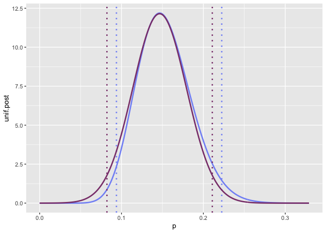

```r
un.norm <- dnorm(p,17/116,1/116 * (17*(116-17)/116)**0.5)
X <- data.frame(p,unif.post,beta.prior,beta.post,un.norm)

(plt<-ggplot(X[X$p<0.33,])+geom_line(aes(p,unif.post),color="#8394f6", lwd=1) +
    geom_vline(xintercept=qbeta(0.025,18,100), color="#8394f6", linetype="dotted", lwd=1) +
    geom_vline(xintercept=qbeta(0.975,18,100), color="#8394f6", linetype="dotted", lwd=1) +
    geom_line(aes(p,un.norm), color="#8b417b", lwd=1)+
    geom_vline(xintercept=qnorm(0.025,17/116,1/116 * (17*(116-17)/116)**0.5), color="#8b417b", linetype="dotted", lwd=1) +
    geom_vline(xintercept=qnorm(0.975,17/116,1/116 * (17*(116-17)/116)**0.5), color="#8b417b", linetype="dotted", lwd=1) )
```

```r
quantities <- c("First moment","Second Moment","lower quantile","upper quantile")
flat_prior <- c(18/118,var_beta(18,100),qbeta(0.025,18,100),qbeta(0.975,18,100))
normal_app <- c(17/116,1/116 * (17*(116-17)/116)**0.5,qnorm(0.025,17/116,1/116 * (17*(116-17)/116)**0.5),qnorm(0.975,17/116,1/116 * (17*(116-17)/116)**0.5))
summary <- data.frame(quantities,flat_prior,normal_app)
summary
```

```
##       quantities  flat_prior normal_app
## 1   First moment 0.152542373 0.14655172
## 2  Second Moment 0.001086329 0.03283636
## 3 lower quantile 0.093802632 0.08219363
## 4 upper quantile 0.222416329 0.21090982
```

### Beta prior and normal approximation

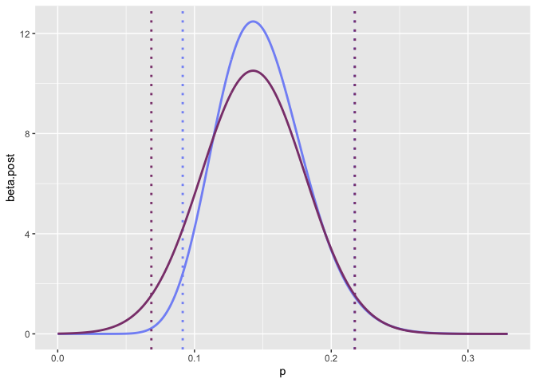

```r
bt.norm <- dnorm(p, 17/119, 1/119 * (1/(1/17-1/102))**0.5)

X <- data.frame(p,unif.post,beta.prior,beta.post,un.norm,bt.norm)

(plt<-ggplot(X[X$p<0.33,])+geom_line(aes(p,beta.post),color="#8394f6", lwd=1) +
    geom_vline(xintercept=qbeta(0.025,18,103), color="#8394f6", linetype="dotted", lwd=1) +
    geom_vline(xintercept=qbeta(0.975,18,103), color="#8394f6", linetype="dotted", lwd=1) +
    geom_line(aes(p,bt.norm), color="#8b417b", lwd=1)+
    geom_vline(xintercept=qnorm(0.025,17/119, 1/119 * (1/(1/17-1/102))**0.5), color="#8b417b", linetype="dotted", lwd=1) +
    geom_vline(xintercept=qnorm(0.975,17/119, 1/119 * (1/(1/17-1/102))**0.5), color="#8b417b", linetype="dotted", lwd=1))
```

```r
quantities <- c("First moment","Second Moment","lower quantile","upper quantile")
beta_prior <- c(17/119,var_beta(18,103),qbeta(0.025,18,103),qbeta(0.975,18,103))
normal_app <- c(17/119,1/119 * (1/(1/17-1/102))**0.5,qnorm(0.025,17/119,1/119 * (1/(1/17-1/102))**0.5),qnorm(0.975,17/119,1/119 * (1/(1/17-1/102))**0.5))
summary <- data.frame(quantities,beta_prior,normal_app)
summary
```

```
##       quantities  beta_prior normal_app
## 1   First moment 0.142857143 0.14285714
## 2  Second Moment 0.001037957 0.03795492
## 3 lower quantile 0.091389573 0.06846686
## 4 upper quantile 0.217106898 0.21724743
```

## Exercise 3 - Coin flip

### Flat prior

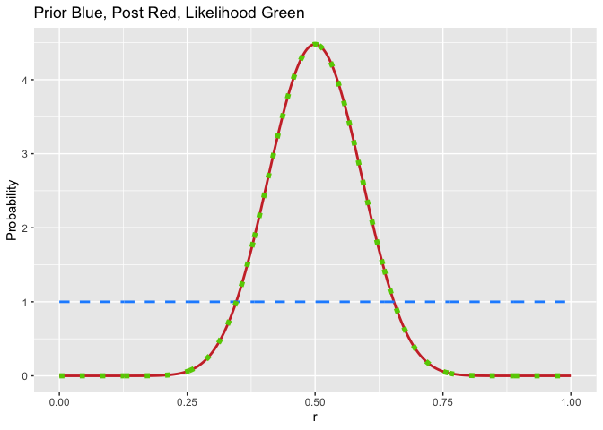

```r
p <- seq(0,1,0.001)
unif.prior <- dbeta(p,1,1)
unif.post <- dbeta(p,16,16)
unif.llhood <- dbinom(15,30,p)/(0.001*sum(dbinom(15,30,p)))
UNIF <- data.frame(p,unif.prior,unif.post,unif.llhood)

(plt<-ggplot(UNIF)+geom_line(aes(p,unif.post), color="brown3", lwd=1) +
  geom_line(aes(p,unif.prior), color="dodgerblue", lwd=1, linetype="dashed") +
  geom_line(aes(p,unif.llhood), color="chartreuse3", lwd=2, linetype="dotted") +
  labs(x="r", y="Probability") + ggtitle("Prior Blue, Post Red, Likelihood Green"))
```

### Beta Prior

One can ask what happens with another beta prior, for example, assuming a fair coin we could use beta(2,2)

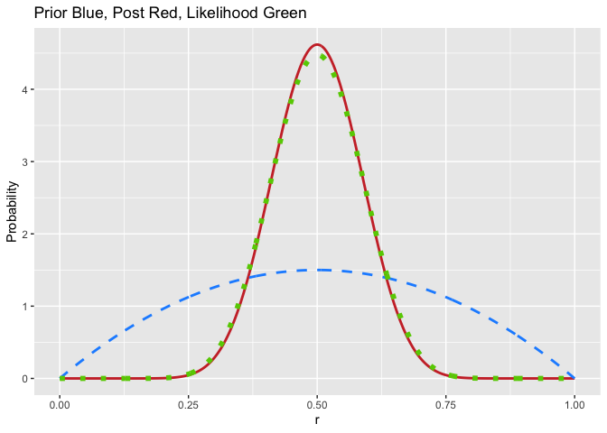

```r
p <- seq(0,1,0.001)
unif.prior <- dbeta(p,2,2)
unif.post <- dbeta(p,17,17)
unif.llhood <- dbinom(15,30,p)/(0.001*sum(dbinom(15,30,p)))
UNIF <- data.frame(p,unif.prior,unif.post,unif.llhood)

(plt<-ggplot(UNIF)+geom_line(aes(p,unif.post), color="brown3", lwd=1) +
  geom_line(aes(p,unif.prior), color="dodgerblue", lwd=1, linetype="dashed") +
  geom_line(aes(p,unif.llhood), color="chartreuse3", lwd=2, linetype="dotted") +
  labs(x="r", y="Probability") + ggtitle("Prior Blue, Post Red, Likelihood Green"))
```

As can be clearly seen the posterior is dominated by the likelihood in both cases, which is to be expected. Regarding most probable value and credibility intervals

```r
quantities <- c("Most probable value","lower quantile","upper quantile")
flat_prior <- c(16/32,qbeta(0.025,16,16),qbeta(0.975,16,16))
beta_prior <- c(17/34,qbeta(0.025,17,17),qbeta(0.975,17,17))
summary <- data.frame(quantities,flat_prior,beta_prior)
summary
```

```
##            quantities flat_prior beta_prior
## 1 Most probable value   0.500000  0.5000000
## 2      lower quantile   0.330606  0.3354445
## 3      upper quantile   0.669394  0.6645555
```

### Sequential Analysis

```r
meas <- c(1,1,1,1,1,0,1,1,0,0,1,1,0,0,0,1,0,1,0,1,0,0,1,0,1,0,1,0,0,0)
```

The sequential analysis accepts as an input any vector of results as the one above (1=H,0=T), the parameters of a generic beta prior and a credibility target percentage and returns, at each step, prior, posterior, likelihood and credibility interval

```r
seqana <- function(res,alpha,beta,credint) {
  prior_alpha <- rep(0,length(res))
  prior_beta <- rep(0,length(res))
  post_alpha <- rep(0,length(res))
  post_beta <- rep(0,length(res))
  llhood_p <- rep(0,length(res))
  llhood_n <- c(1:length(res))
  lowq <- rep(0,length(res))
  highq <- rep(0,length(res))
  try_num <- c(1:length(res))
  tot <- data.frame(try_num,res,prior_alpha,prior_beta,post_alpha,post_beta,llhood_n,llhood_p,lowq,highq)

  tot$prior_alpha[1] = alpha
  tot$prior_beta[1] = beta

  p1 <- (1-credint)/2
  p2 <- (1+credint)/2

  for (i in c(1:length(res))) {

    llh <- tot[tot$try_num <= i,]
    llh <- llh[llh$res == 1,]
    r <- nrow(llh)
    tot$llhood_p[i] <- r

    if (res[i]==1) {
      tot$post_alpha[i] <- tot$prior_alpha[i] + 1
      tot$post_beta[i] <- tot$prior_beta[i]
    }

    if (res[i]==0) {
      tot$post_alpha[i] <- tot$prior_alpha[i]
      tot$post_beta[i] <- tot$prior_beta[i] + 1
    }

    if(i < length(res)) {
      tot$prior_alpha[i+1] <- tot$post_alpha[i]
      tot$prior_beta[i+1] <- tot$post_beta[i]
    }

    a <- tot$post_alpha[i]
    b <- tot$post_alpha[i]

    tot$lowq[i] <- qbeta(p1,a,b)
    tot$highq[i] <- qbeta(p2,a,b)
  }
  return(tot)
}

tot <- seqana(meas,1,1,0.95)
```

I will plot the analysis for try_num=1,2,5,12,17,30. As before prior is in blue, posterior in red and likelihood in green

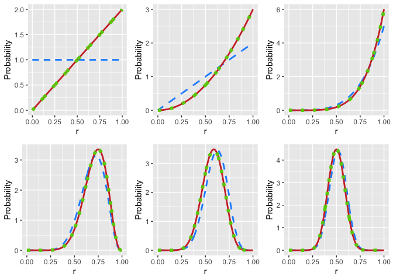

```r
pl.prior <- dbeta(p,tot[tot$try_num==1,"prior_alpha"],tot[tot$try_num==1,"prior_beta"])
pl.post <- dbeta(p,tot[tot$try_num==1,"post_alpha"],tot[tot$try_num==1,"post_beta"])
pl.llhood <- dbinom(tot[tot$try_num==1,"llhood_p"],tot[tot$try_num==1,"llhood_n"],p)/
  (0.001*sum(dbinom(tot[tot$try_num==1,"llhood_p"],tot[tot$try_num==1,"llhood_n"],p)))
pltot <- data.frame(p,pl.prior,pl.post,pl.llhood)

pl_0 <- ggplot(pltot) + geom_line(aes(p,pl.prior),color="dodgerblue", lwd=1, linetype="dashed") + geom_line(aes(p,pl.post), color="brown3", lwd=1) + geom_line(aes(p,pl.llhood), color="chartreuse3", lwd=2, linetype="dotted")+labs(x="r", y="Probability")


pl.prior <- dbeta(p,tot[tot$try_num==2,"prior_alpha"],tot[tot$try_num==2,"prior_beta"])
pl.post <- dbeta(p,tot[tot$try_num==2,"post_alpha"],tot[tot$try_num==2,"post_beta"])
pl.llhood <- dbinom(tot[tot$try_num==2,"llhood_p"],tot[tot$try_num==2,"llhood_n"],p)/
  (0.001*sum(dbinom(tot[tot$try_num==2,"llhood_p"],tot[tot$try_num==2,"llhood_n"],p)))
pltot <- data.frame(p,pl.prior,pl.post,pl.llhood)

pl_1 <- ggplot(pltot) + geom_line(aes(p,pl.prior),color="dodgerblue", lwd=1, linetype="dashed") + geom_line(aes(p,pl.post), color="brown3", lwd=1) + geom_line(aes(p,pl.llhood), color="chartreuse3", lwd=2, linetype="dotted")+labs(x="r", y="Probability")


pl.prior <- dbeta(p,tot[tot$try_num==5,"prior_alpha"],tot[tot$try_num==5,"prior_beta"])
pl.post <- dbeta(p,tot[tot$try_num==5,"post_alpha"],tot[tot$try_num==5,"post_beta"])
pl.llhood <- dbinom(tot[tot$try_num==5,"llhood_p"],tot[tot$try_num==5,"llhood_n"],p)/
  (0.001*sum(dbinom(tot[tot$try_num==5,"llhood_p"],tot[tot$try_num==5,"llhood_n"],p)))
pltot <- data.frame(p,pl.prior,pl.post,pl.llhood)

pl_2 <- ggplot(pltot) + geom_line(aes(p,pl.prior),color="dodgerblue", lwd=1, linetype="dashed") + geom_line(aes(p,pl.post), color="brown3", lwd=1) + geom_line(aes(p,pl.llhood), color="chartreuse3", lwd=2, linetype="dotted")+labs(x="r", y="Probability")


pl.prior <- dbeta(p,tot[tot$try_num==12,"prior_alpha"],tot[tot$try_num==12,"prior_beta"])
pl.post <- dbeta(p,tot[tot$try_num==12,"post_alpha"],tot[tot$try_num==12,"post_beta"])
pl.llhood <- dbinom(tot[tot$try_num==12,"llhood_p"],tot[tot$try_num==12,"llhood_n"],p)/
  (0.001*sum(dbinom(tot[tot$try_num==12,"llhood_p"],tot[tot$try_num==12,"llhood_n"],p)))
pltot <- data.frame(p,pl.prior,pl.post,pl.llhood)

pl_3 <- ggplot(pltot) + geom_line(aes(p,pl.prior),color="dodgerblue", lwd=1, linetype="dashed") + geom_line(aes(p,pl.post), color="brown3", lwd=1) + geom_line(aes(p,pl.llhood), color="chartreuse3", lwd=2, linetype="dotted")+labs(x="r", y="Probability")


pl.prior <- dbeta(p,tot[tot$try_num==17,"prior_alpha"],tot[tot$try_num==17,"prior_beta"])
pl.post <- dbeta(p,tot[tot$try_num==17,"post_alpha"],tot[tot$try_num==17,"post_beta"])
pl.llhood <- dbinom(tot[tot$try_num==17,"llhood_p"],tot[tot$try_num==17,"llhood_n"],p)/
  (0.001*sum(dbinom(tot[tot$try_num==17,"llhood_p"],tot[tot$try_num==17,"llhood_n"],p)))
pltot <- data.frame(p,pl.prior,pl.post,pl.llhood)

pl_4 <- ggplot(pltot) + geom_line(aes(p,pl.prior),color="dodgerblue", lwd=1, linetype="dashed") + geom_line(aes(p,pl.post), color="brown3", lwd=1) + geom_line(aes(p,pl.llhood), color="chartreuse3", lwd=2, linetype="dotted")+labs(x="r", y="Probability")


pl.prior <- dbeta(p,tot[tot$try_num==30,"prior_alpha"],tot[tot$try_num==30,"prior_beta"])
pl.post <- dbeta(p,tot[tot$try_num==30,"post_alpha"],tot[tot$try_num==30,"post_beta"])
pl.llhood <- dbinom(tot[tot$try_num==30,"llhood_p"],tot[tot$try_num==30,"llhood_n"],p)/
  (0.001*sum(dbinom(tot[tot$try_num==30,"llhood_p"],tot[tot$try_num==30,"llhood_n"],p)))
pltot <- data.frame(p,pl.prior,pl.post,pl.llhood)

pl_5 <- ggplot(pltot) + geom_line(aes(p,pl.prior),color="dodgerblue", lwd=1, linetype="dashed") + geom_line(aes(p,pl.post), color="brown3", lwd=1) + geom_line(aes(p,pl.llhood), color="chartreuse3", lwd=2, linetype="dotted")+labs(x="r", y="Probability")

(plot <- ggarrange(pl_0,pl_1,pl_2,pl_3,pl_4,pl_5, nrow=2, ncol=3, heights = c(1,1)))
```

### Results comparison

Is the sequential analysis the same as the “batch” analysis?

```r
(tot[tot$try_num==30,c("post_alpha","post_beta")])
```

```
##    post_alpha post_beta
## 30         16        16
```

As we can see results are the same, as expected

## Exercise 4

Probability computation starts after the first extraction, a flat prior is assumed

```r
extraction <- function(N) {
  #simulate box choice
  p <- floor(runif(1,0,6))/(5)
  #simulate extraction according to box chosen
  res <- rbinom(N,1,p)
  #initialize relevant quantities
  p_0 <- rep(0,N)
  p_1 <- rep(0,N)
  p_2 <- rep(0,N)
  p_3 <- rep(0,N)
  p_4 <- rep(0,N)
  p_5 <- rep(0,N)
  p_w <- seq(0,1,0.2)
  p_b <- seq(1,0,-0.2)
  try_num <- c(1:N)

  #first iteration
  if (res[1]==1) {
    p_0[1] <- p_w[1] * 0.2
    p_1[1] <- p_w[2] * 0.2
    p_2[1] <- p_w[3] * 0.2
    p_3[1] <- p_w[4] * 0.2
    p_4[1] <- p_w[5] * 0.2
    p_5[1] <- p_w[6] * 0.2

    nm <- 1/sum(p_0[1],p_1[1],p_2[1],p_3[1],p_4[1],p_5[1])

    p_0[1] <- p_0[1] * nm
    p_1[1] <- p_1[1] * nm
    p_2[1] <- p_2[1] * nm
    p_3[1] <- p_3[1] * nm
    p_4[1] <- p_4[1] * nm
    p_5[1] <- p_5[1] * nm
  }

    if (res[1]==0) {
    p_0[1] <- p_b[1] * 0.2
    p_1[1] <- p_b[2] * 0.2
    p_2[1] <- p_b[3] * 0.2
    p_3[1] <- p_b[4] * 0.2
    p_4[1] <- p_b[5] * 0.2
    p_5[1] <- p_b[6] * 0.2

    nm <- 1/sum(p_0[1],p_1[1],p_2[1],p_3[1],p_4[1],p_5[1])

    p_0[1] <- p_0[1] * nm
    p_1[1] <- p_1[1] * nm
    p_2[1] <- p_2[1] * nm
    p_3[1] <- p_3[1] * nm
    p_4[1] <- p_4[1] * nm
    p_5[1] <- p_5[1] * nm
  }

  #other iterations
  for (i in c(2:N)){
      if (res[i]==1) {
    p_0[i] <- p_w[1] * p_0[i-1]
    p_1[i] <- p_w[2] * p_1[i-1]
    p_2[i] <- p_w[3] * p_2[i-1]
    p_3[i] <- p_w[4] * p_3[i-1]
    p_4[i] <- p_w[5] * p_4[i-1]
    p_5[i] <- p_w[6] * p_5[i-1]

    nm <- 1/sum(p_0[i],p_1[i],p_2[i],p_3[i],p_4[i],p_5[i])

    p_0[i] <- p_0[i] * nm
    p_1[i] <- p_1[i] * nm
    p_2[i] <- p_2[i] * nm
    p_3[i] <- p_3[i] * nm
    p_4[i] <- p_4[i] * nm
    p_5[i] <- p_5[i] * nm
  }

    if (res[i]==0) {
    p_0[i] <- p_b[1] * p_0[i-1]
    p_1[i] <- p_b[2] * p_1[i-1]
    p_2[i] <- p_b[3] * p_2[i-1]
    p_3[i] <- p_b[4] * p_3[i-1]
    p_4[i] <- p_b[5] * p_4[i-1]
    p_5[i] <- p_b[6] * p_5[i-1]

    nm <- 1/sum(p_0[i],p_1[i],p_2[i],p_3[i],p_4[i],p_5[i])

    p_0[i] <- p_0[i] * nm
    p_1[i] <- p_1[i] * nm
    p_2[i] <- p_2[i] * nm
    p_3[i] <- p_3[i] * nm
    p_4[i] <- p_4[i] * nm
    p_5[i] <- p_5[i] * nm
  }

  }

  #create dataframe for plotting
  res <- data.frame(try_num,res,p_0,p_1,p_2,p_3,p_4,p_5)
  return(res)
}
```

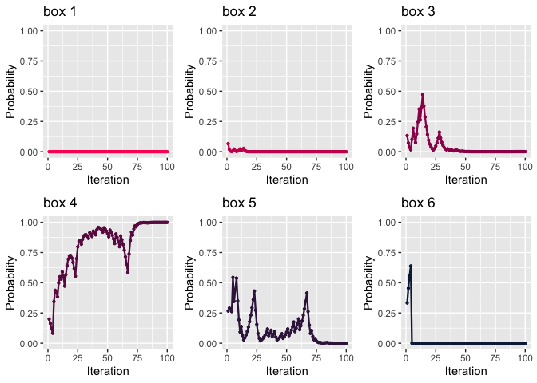

```r
set.seed(12348)
res <- extraction(100)
#plotting
pl_0 <- ggplot(res, aes(try_num,p_0)) + geom_point(size=0.8, color="#fd0363") + geom_line(lwd=0.8, color="#fd0363") + ylim(0,1) + labs(x="Iteration", y="Probability") + ggtitle("box 1")

pl_1 <- ggplot(res, aes(try_num,p_1)) + geom_point(size=0.8, color="#cc095d") + geom_line(lwd=0.8, color="#cc095d") + ylim(0,1) + labs(x="Iteration", y="Probability") + ggtitle("box 2")

pl_2 <- ggplot(res, aes(try_num,p_2)) + geom_point(size=0.8, color="#9c1057") + geom_line(lwd=0.8, color="#9c1057") + ylim(0,1) + labs(x="Iteration", y="Probability") + ggtitle("box 3")

pl_3 <- ggplot(res, aes(try_num,p_3)) + geom_point(size=0.8, color="#6b1650") + geom_line(lwd=0.8, color="#6b1650") + ylim(0,1) + labs(x="Iteration", y="Probability") + ggtitle("box 4")

pl_4 <- ggplot(res, aes(try_num,p_4)) + geom_point(size=0.8, color="#3b1d4a") + geom_line(lwd=0.8, color="#3b1d4a") + ylim(0,1) + labs(x="Iteration", y="Probability") + ggtitle("box 5")

pl_5 <- ggplot(res, aes(try_num,p_5)) + geom_point(size=0.8, color="#0a2344") + geom_line(lwd=0.8, color="#0a2344") + ylim(0,1) + labs(x="Iteration", y="Probability") + ggtitle("box 6")

(plot <- ggarrange(pl_0,pl_1,pl_2,pl_3,pl_4,pl_5, nrow=2, ncol=3, heights = c(1,1)))
```

For this seed box 4 is the most probable result